# Moneta

Aina Petronytė

2016 m spalis 12 d

## Moneta

Tarkime metama moneta. Jeigu iškrenta herbas, tai laimite 12 EUR. Jeigu skaičius, tai pralošiate 10 EUR. Bus žaidžiama 100 kartų ir gauti rezultatai sumuojami. Pirmiausia surandame galimus balanso variantus pagal iškritusių herbų skaičių:

```r
herbai <- 0:100 #herbu skaicius
balansas <- replicate(100,0)
for (i in 1:101){
  balansas[i] = herbai[i]*12-(100-herbai[i])*10
}
balansas #galimi variantai
```

```
##   [1] -1000  -978  -956  -934  -912  -890  -868  -846  -824  -802  -780
##  [12]  -758  -736  -714  -692  -670  -648  -626  -604  -582  -560  -538
##  [23]  -516  -494  -472  -450  -428  -406  -384  -362  -340  -318  -296
##  [34]  -274  -252  -230  -208  -186  -164  -142  -120   -98   -76   -54
##  [45]   -32   -10    12    34    56    78   100   122   144   166   188
##  [56]   210   232   254   276   298   320   342   364   386   408   430
##  [67]   452   474   496   518   540   562   584   606   628   650   672
##  [78]   694   716   738   760   782   804   826   848   870   892   914
##  [89]   936   958   980  1002  1024  1046  1068  1090  1112  1134  1156
## [100]  1178  1200
```

Dabar galime įvertinti, kurie yra teigiami, o kurie neigiami:

```r
teigiamas <- balansas > 0
sum(!teigiamas)
```

```
## [1] 46
```

```r
herbai[46]
```

```
## [1] 45
```

Išsiaiškinome, kad pirmieji 46 variantai nėra teigiami ir 46 varianto herbų skaičius yra 45. Taigi, teigiamo balanso tikimybė lygi tikimybei, kad herbų skaičius didesnis nei 45. Kadangi monetos metimas turi binominį skirstinį, pasinaudosime binominio skirstinio tikimybės formule:

```r
tikimybe <- pbinom(45, 100, 0.5, lower.tail=FALSE)
tikimybe
```

```
## [1] 0.8158992
```

```r
qbinom(tikimybe, 100, 0.5, lower.tail = FALSE)
```

```
## [1] 45
```

```r
qbinom(tikimybe, 100, 0.5)
```

```
## [1] 54
```

```r
balansas[44]
```

```
## [1] -54
```

```r
balansas[53]
```

```
## [1] 144
```

Nubraižysime balanso tankio funkciją. Pirmiausia sukursime vektorių iš visų balanso reikšmių tankio, naudodami binominio skirstinio tankio funkciją kiekvienam herbų skaičiui, ir pavaizduosime tankio priklausomybę nuo balanso:

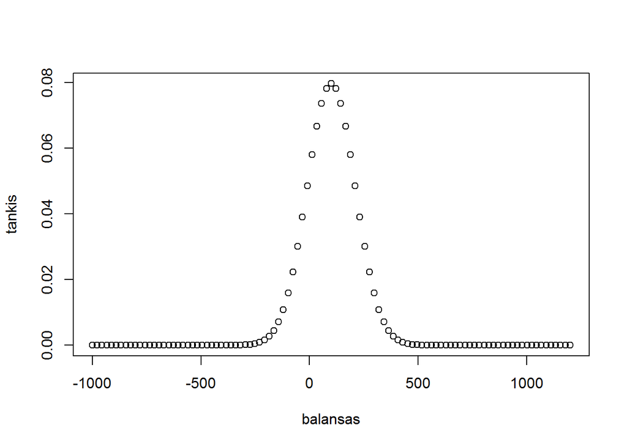

```r
tankis <- dbinom(herbai, 100, prob=0.5)
plot(balansas,tankis)
```

Taip atrodo balanso tankis.

Šaltiniai:

R help